# 삼성디스플레이 89조 원의 그림자

비상장 지배구조 재편, 삼성SDI의 4.45조 원 현금화, 그리고 OLED의 다음 5년

저자

Alpha Hunter × Chimera AI

공개

2026년 8월 22일

삼성디스플레이는 2025년 매출 약 29.8조 원을 기록한 대형 비상장사다. 2026년 8월 21일 삼성SDI가 지분 5%를 4.45조 원에 삼성디스플레이로 넘기면서 약 89조 원의 암시 지분가치가 드러났다. 그러나 이는 특수관계인 거래가격이지 공개시장의 시가총액이 아니다. **삼성전자와 삼성SDI를 삼성디스플레이의 대용주로 단순 매수하는 판단도 보류한다.**

# 1 한눈에 보는 결론

이번 거래는 삼성디스플레이의 IPO 신호가 아니다. 오히려 삼성SDI가 현금을 확보하고 삼성전자의 유효 지배력이 높아지는 **그룹 내부 자본 재배치**다. 거래 후에도 삼성전자의 명목 지분 84.78%는 그대로지만, 삼성디스플레이가 취득한 자기주식 약 5%에는 의결권이 없으므로 삼성전자의 유효 의결권은 약 89.24%로 올라간다. 자기주식 소각은 별도 확정 공시가 필요하다.

핵심 숫자는 다음과 같다.

| 검토 축 | 확인값 | Alpha Hunter 해석 |
| --- | --- | --- |
| 매각 주식 | 13,088,235주 | 삼성SDI 보유분의 약 3분의 1, 총발행주식의 약 5% |
| 거래대금 | 4.45조 원 | 삼성디스플레이 현금 유출, 삼성SDI 현금 유입 |
| 거래단가 | 주당 약 34만 원 | 공개시장 가격이 아닌 특수관계인 거래단가 |
| 암시 지분가치 | 약 89.0조 원 | IPO 가치나 목표 시총으로 직접 사용 금지 |
| 삼성SDI 잔여지분 | 10.22%, 동일 단가 약 9.1조 원 | 배터리 기업 안에 남은 비상장 자산 |
| 2025 SDC 실적 | 매출 약 29.9조, OP 약 4.2조 | 분기 공식 수치 합산, 반올림 차이 있음 |
| 2026 상반기 | 매출 14.2조, OP 1.1조 | 계절성 저점 이후 Q2 회복, H2 검증 필요 |

삼성SDI의 공식 공시 목록은 8월 21일 `특수관계인에대한주식의처분`과 `타법인주식및출자증권양도결정` 제출을 확인한다. 보도된 공시 수치는 1,308만8,235주, 4조4,499억9,990만 원, 지분율 15.2%에서 10.2%로의 하락이다. [삼성SDI 공시 목록](https://ir.gsifn.io/samsungsdi/ir3_disclosure.html) · [거래 수치](https://www.yna.co.kr/view/AKR20260821136751003)

# 2 지배구조: 삼성전자의 지배력은 더 강해진다

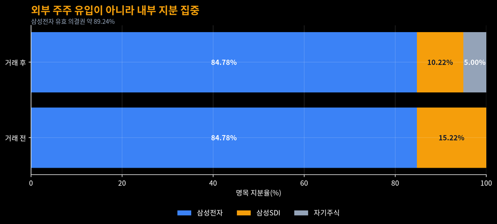

그림 1: 그림 1. 거래 전후 삼성디스플레이 지분 구성. 거래 후 자기주식은 의결권이 없으며 소각은 아직 별도 확인 대상이다.

거래 전 삼성디스플레이의 주주는 사실상 삼성전자와 삼성SDI 두 회사뿐이었다. 거래 후에도 외부 자본은 들어오지 않는다. 삼성디스플레이가 자기 현금으로 삼성SDI 지분을 사기 때문이다. 따라서 지배구조의 방향은 분산이 아니라 집중이다.

다만 삼성전자 주주에게 무조건 공짜 호재는 아니다. 삼성전자는 유효 지분율을 높이는 대신, 연결 대상인 삼성디스플레이에서 현금 4.45조 원이 빠져나가는 효과를 함께 감수한다. 반대로 삼성SDI는 투자재원을 얻지만 미래 삼성디스플레이 배당과 자산가치의 5%를 포기한다.

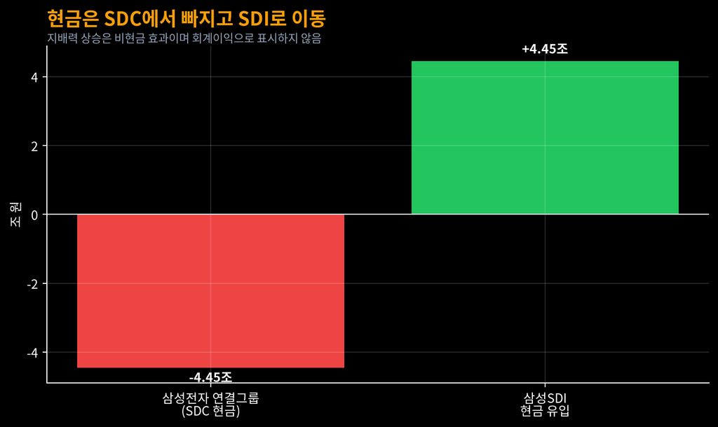

그림 2: 그림 2. 거래 종결 시 예상되는 현금 방향. 세금·거래비용과 연결조정 전 단순 표시다.

삼성전자의 유효 지배력 상승은 비현금 효과이며 실제 연결회계 손익과 동일하지 않다. 이 구분을 하지 않으면 “삼성전자가 4.45조 원으로 자회사를 더 샀다”거나 “아무 비용 없이 지분율이 올랐다”는 잘못된 결론에 도달한다.

# 3 89조 원은 무엇을 뜻하는가

거래대금을 매각주식수로 나누면 주당 약 34만 원이다. 이를 총발행주식수에 곱하면 약 89.0조 원이 나온다. 2025년 공식 분기 실적 합산과 비교하면 매출 대비 약 3.0배, 영업이익 대비 약 21.2배다. 후자는 순이익 기준 PER가 아니라 `지분가치/영업이익`이라는 거친 비교치다.

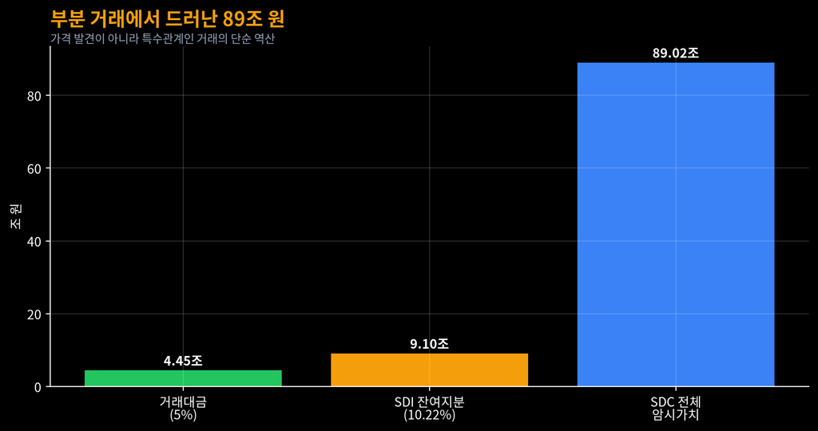

그림 3: 그림 3. 거래단가가 암시하는 지분가치. 관련자 거래이므로 공개시장 가치와 동일시할 수 없다.

89조 원을 곧바로 적정가치라고 부를 수 없는 이유는 세 가지다.

1. 거래 당사자가 독립적인 공개시장 투자자가 아니라 삼성 계열사다.
2. 비상장사라 실시간 가격 발견과 소수주주 할인·유동성 할인이 없다.
3. 공시 원문에 첨부된 전체 외부평가 세부 가정을 이 보고서에서 직접 재검증하지 못했다.

따라서 89조 원은 **가치의 단서**이지 목표 시가총액이 아니다. 다만 삼성SDI 장부 안에 있던 삼성디스플레이 지분이 단순한 회계상 숫자가 아니라 대규모 현금화 가능한 자산이라는 사실은 확인됐다.

# 4 이익은 강하지만 계절성이 크다

삼성전자 공식 실적발표를 분기별로 합산하면 삼성디스플레이의 2025년 매출은 약 29.9조 원, 영업이익은 약 4.2조 원이다. 삼성전자의 연간 데이터가 제시한 순매출 29.8조 원과 0.1조 원 차이가 나는 것은 분기 수치가 0.1조 원 단위로 반올림됐기 때문이다. 2026년 상반기는 매출 14.2조 원, 영업이익 1.1조 원이다.

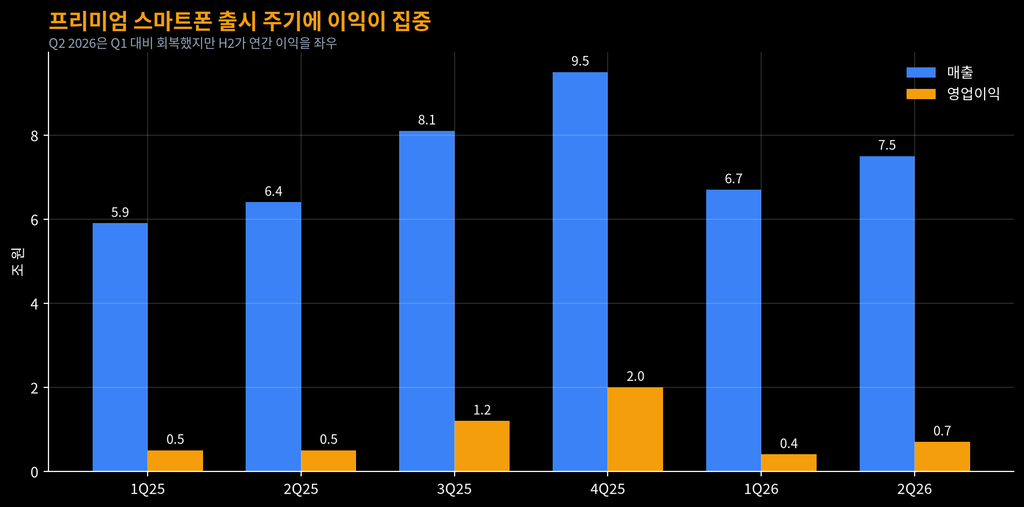

그림 4: 그림 4. 삼성전자 공식 발표의 SDC 분기 실적. 2025년 Q4 집중과 2026년 상반기 계절성을 동시에 보여준다.

2025년 4분기 매출 9.5조 원과 영업이익 2.0조 원은 연간 이익의 절반 가까이를 차지했다. 이는 높은 수익성과 동시에 주요 고객의 플래그십 출시 일정에 대한 의존성을 보여준다. 2026년 2분기는 매출 7.5조 원, 영업이익 0.7조 원으로 1분기보다 개선됐다. 삼성은 고급 모바일 OLED와 게이밍 모니터 수요를 배경으로 설명했고, 하반기에는 저전력·다양한 폼팩터·8.6세대 IT OLED 양산을 성장축으로 제시했다. [삼성전자 2026년 2분기 공식 실적](https://news.samsung.com/global/samsung-electronics-announces-second-quarter-2026-results)

# 5 미래 5년: 모바일의 현금을 IT·Auto·XR로 옮길 수 있는가

## 5.1 8.6세대 IT OLED가 가장 중요한 시험대

삼성디스플레이는 아산 A6 라인에 2026년까지 4.1조 원을 투자하고 연간 약 1천만 개의 노트북 패널 생산능력을 구축한다고 밝혔다. 공식 자료가 인용한 Omdia 전망은 IT OLED 시장매출이 2024년 25.34억 달러에서 2029년 89.13억 달러로 성장한다는 것이다. [삼성디스플레이 8.6G 공식 발표](https://news.samsungdisplay.com/34177?type=main)

투자 논리는 명확하다. 스마트폰보다 큰 원판을 효율적으로 잘라 노트북·태블릿 원가를 낮추고, 모바일 중심 고객·제품 구성을 넓힌다. 그러나 대규모 기판의 증착 균일도, 수율, 수명, 고객 채택 속도가 기대에 못 미치면 감가상각이 먼저 이익을 압박한다.

## 5.2 QD-OLED는 TV보다 게이밍 모니터에서 먼저 증명

2026년 2분기 공식 실적은 대형 디스플레이 판매량과 매출 확대의 배경으로 게이밍 모니터를 지목했다. QD-OLED의 빠른 응답속도와 고주사율은 가격 프리미엄을 설명하기 쉽다. 반면 TV에서는 WOLED와 Mini LED LCD가 크기·가격·밝기로 경쟁한다. 따라서 단기 수익화의 중심은 프리미엄 TV 전체가 아니라 게이밍·전문가용 모니터일 가능성이 높다.

## 5.3 자동차와 OLEDoS는 긴 옵션

차량용 OLED는 인증기간이 길지만 채택 후 공급기간도 길다. XR용 OLEDoS는 5,000PPI RGB, 20,000니트급 시제품이 공개됐지만 시장규모가 아직 작다. 2025년 공식 기술 요약은 IT OLED, 34형 차량용 OLED, 저전력 기술, 폴더블, OLEDoS를 다섯 축으로 제시했다. [SDC 2025 기술 하이라이트](https://news.samsungdisplay.com/34416)

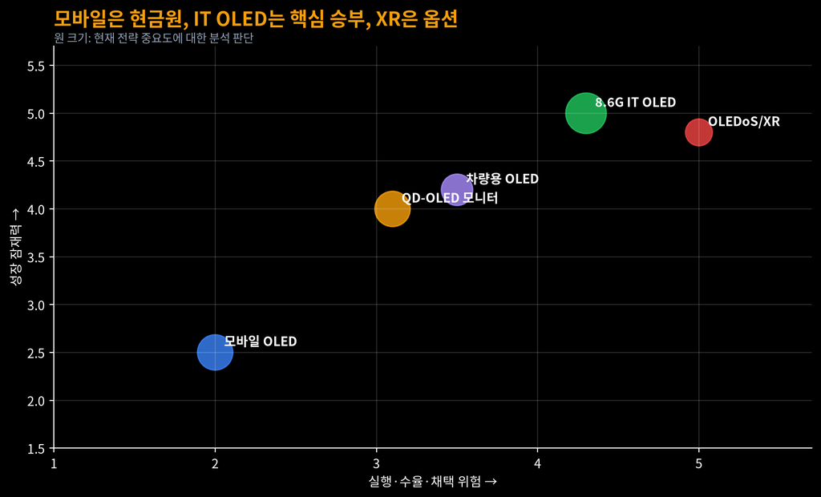

그림 5: 그림 5. Alpha Hunter 성장지도. 점수는 공식 가이던스를 바탕으로 한 분석 프레임이며 시장규모 예측치가 아니다.

# 6 상장 가능성: 지금은 낮다

삼성디스플레이는 상장 없이도 자체 현금흐름과 삼성전자 연결 자회사 지위를 활용해 대규모 투자를 집행해 왔다. 상장하면 가치가 공개되고 자금조달 창구가 넓어지지만 다음 비용이 생긴다.

- 삼성전자에 이미 포함된 사업을 다시 상장하는 중복상장 논란
- 고객·수율·제품 로드맵에 대한 공시 부담
- 외부 소수주주와 삼성전자 주주의 이해상충
- 장기 설비투자보다 분기실적과 주주환원 압력 증가

이번 거래는 외부 투자자에게 지분을 분산한 것이 아니라 삼성디스플레이가 자기주식을 취득한 것이다. **확인된 사실만 놓고 보면 IPO보다 삼성전자 중심의 지배력 강화에 가깝다.** 향후 삼성SDI가 남은 10.22%를 추가 매각할 가능성은 열려 있지만, 그것 역시 곧 IPO를 의미하지 않는다.

# 7 투자 경로: 무엇을 사야 하는가

## 7.1 삼성전자 — 가장 직접적인 영업실적 노출

삼성전자는 삼성디스플레이를 연결하므로 매출과 영업이익이 실적에 포함된다. 그러나 2025년 SDC 순매출 29.8조 원은 삼성전자 사업부문 합계에서 약 8%였다. 주가는 메모리·파운드리·스마트폰 영향이 훨씬 크다. 삼성디스플레이만 보고 삼성전자를 매수하는 것은 촉매가 희석된다.

## 7.2 삼성SDI — 자산가치가 더 잘 보이지만 본업은 배터리

이번 거래단가로 환산한 잔여지분 가치는 약 9.1조 원이다. 4.45조 원의 현금 유입은 미국 생산시설, ESS, LFP, 전고체 등 투자 여력을 높인다. 반면 향후 삼성디스플레이 배당과 지분가치가 줄었고, 확보한 현금을 배터리 사업에서 높은 수익률로 전환해야 한다. **자산을 팔았다는 사실보다 재투자수익률이 중요하다.**

## 7.3 장비·소재 — 수주 확인 전에는 테마

8.6G 설비 반입식에는 캐논도키, 원익IPS, 파인엠텍, HBT, ICD, LOT Vacuum 등이 참석했다. 그러나 행사 참석이 곧 수주·매출·이익을 보장하지 않는다. 개별 공급사의 공시 수주, 삼성디스플레이 매출 비중, 고객 다변화와 밸류에이션을 따로 확인하기 전에는 매수 후보가 아니라 관찰 목록이다.

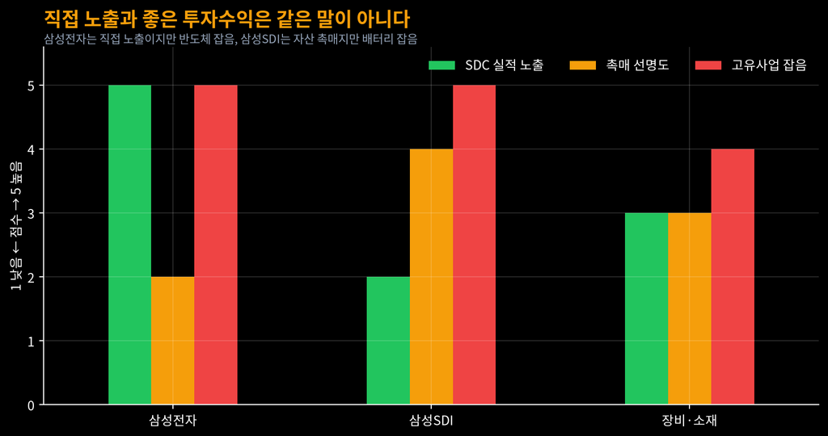

그림 6: 그림 6. 삼성디스플레이 테마의 상장시장 전달력. 점수는 Alpha Hunter의 정성적 분석이다.

# 8 가설 파기 조건과 체크리스트

## 8.1 긍정 가설이 강화되는 조건

1. 8.6G IT OLED가 공식 일정대로 양산되고 초기 수율·고객승인이 안정된다.
2. 2026년 하반기 SDC 영업이익이 계절성 회복을 넘어 전년 수준을 방어한다.
3. QD-OLED 모니터 고객과 제품 수가 늘고 대형사업 수익성이 개선된다.
4. 자동차용 OLED가 MOU가 아닌 장기 양산수주로 전환된다.
5. 삼성SDI가 4.45조 원을 저수익 적자보전에 쓰지 않고 ESS·전고체 등 고수익 성장으로 전환한다.

## 8.2 즉시 경계 또는 가설 파기

- 8.6G 양산 지연, 초기 수율 미달, 고객 채택 연기 중 두 가지 이상 발생
- 중국 업체의 8.6G 가동과 주요 고객 이원화로 가격·물량이 동시에 하락
- SDC 분기 영업이익률이 성수기에도 한 자릿수에 머묾
- 추가 지분 매각이 성장투자보다 반복적인 현금 부족 보전에 사용
- 삼성디스플레이 자기주식 처리와 관련자 거래가격의 산정 근거가 불투명하게 남음

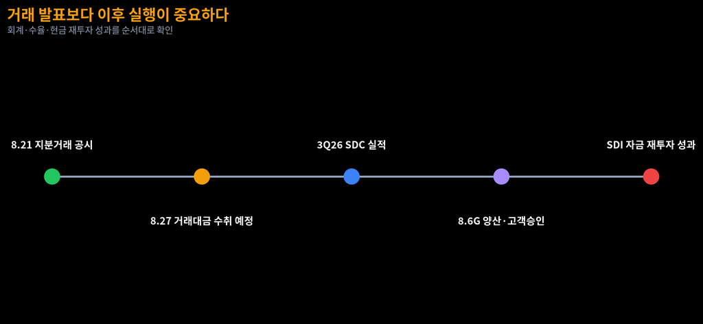

그림 7: 그림 7. 향후 확인 순서. 일정은 회사 공식 발표와 실적 공시 기준으로 갱신해야 한다.

# 9 최종 판단

삼성디스플레이는 매출 30조 원 안팎, 연간 수조 원의 영업이익을 창출하는 비상장 핵심회사다. 이번 거래는 숨겨진 가치의 일부를 숫자로 보여줬지만, 89조 원이라는 숫자만 보고 삼성전자나 삼성SDI를 매수해서는 안 된다.

지배구조 관점의 결론은 **삼성전자 통제 강화**, 삼성SDI 관점의 결론은 **알짜 지분을 현금으로 바꾼 재투자 시험**, 사업 관점의 결론은 **모바일 OLED 현금을 8.6G IT OLED·QD-OLED·Auto·XR로 이전하는 전환기**다.

Alpha Hunter의 현재 판정은 `직접 추천 없음·관찰 강화`다. 다음 판단은 3분기 SDC 수익성, 8.6G 양산·고객 승인, 삼성SDI의 4.45조 원 실제 사용처가 확인된 뒤 내려야 한다.

## 9.1 출처와 계산 기준

- [삼성SDI 공시정보 — DART 제공](https://ir.gsifn.io/samsungsdi/ir3_disclosure.html)
- [삼성SDI 지분 거래 수치 — 연합뉴스](https://www.yna.co.kr/view/AKR20260821136751003)
- [Samsung Electronics FY2025 공식 실적](https://news.samsung.com/global/samsung-electronics-announces-fourth-quarter-and-fy-2025-results)
- [Samsung Electronics Q1 2025 공식 실적](https://news.samsung.com/global/samsung-electronics-announces-first-quarter-2025-results)
- [Samsung Electronics Q2 2025 공식 실적](https://news.samsung.com/nl/samsung-electronics-announces-second-quarter-2025-results)
- [Samsung Electronics Q3 2025 공식 실적](https://news.samsung.com/nl/samsung-electronics-announces-third-quarter-2025-results)
- [Samsung Electronics Q1 2026 공식 실적](https://news.samsung.com/ca/samsung-electronics-announces-first-quarter-2026-results)
- [Samsung Electronics Q2 2026 공식 실적](https://news.samsung.com/global/samsung-electronics-announces-second-quarter-2026-results)
- [삼성전자 사업부문별 2025 순매출](https://www.samsung.com/sec/sustainability/digital-library/facts-figures/)
- [삼성디스플레이 8.6G IT OLED 공식 발표](https://news.samsungdisplay.com/34177?type=main)
- [삼성디스플레이 2025 기술 하이라이트](https://news.samsungdisplay.com/34416)

계산은 공시 수치에 고정했다. 총발행주식은 거래 전 삼성전자 221,968,820주와 삼성SDI 39,856,654주의 합계로 놓았다. 유효 의결권은 자기주식을 제외한 주식수 기준이다. 거래가치 역산은 세금, 거래비용, 순현금·순부채, 소수주주 할인과 유동성 할인을 반영하지 않는다.

*Alpha Hunter Governance Special · 2026.08.22 · Nakcho Choi × Chimera AI*  
*면책: 본 문서는 정보·연구 목적의 산업 및 지배구조 분석이며 실제 투자 자문이나 매수·매도 권유가 아니다.*